# Fair Market Rents (FMR) vs Market Rate Rents

2024-12-16

## Project Overview

#### **Goal of the Project**

Analyze if market rate apartment rents are consistent with federal defined [Fair Market Rents (FMR)](https://www.huduser.gov/periodicals/ushmc/winter98/summary-2.html) levels in three distinct metropolitan areas.

#### **What is FMR?**

- FMR is the 40th percentile of gross rents for typical rental units paid by tenants that moved within the last 20 months.
- FMR provides an estimate for rents for the fiscal year starting Oct 2024-Sept 2025
- FMR is used to establish benefits such as the Housing Choice Vouchers used to help unhoused individuals find permanent housing.

## Project Overview (cont.)

#### **Potential Problem**

FMR is an annually-released estimate that data does not capture the real-time economic realities that drive local housing markets.

#### **Implications of Problem**

Some individuals that are approved for housing assistance benefits are unable to find an apartment locally that they can pay for with their approved voucher amount based on their area’s FMR. In other words, market rates tend to outpace FMR estimates when market conditions quickly drive rental prices up in certain areas.

## About the Data

#### **Data sources**

- FMR data pulled from HUD using their publicly available [API](https://www.huduser.gov/portal/dataset/fmr-api.html).
- Market rate data was scraped from the rental listing site [Trulia](http://trulia.com)

#### **Narrowing our Data**

- Atlanta (GA), Buffalo (NY) and San Diego (CA) Metropolitan Areas
- Apartments less than 3 bedrooms

## Working with the HUD API

https://www.huduser.gov/portal/dataset/fmr-api.html

```r
# Custom function to call HUD FMR & IL API
call_hud <- function(endpoint) {

  # init request
  req <- request("https://www.huduser.gov") |>   #domain
    req_headers("Accept" = "application/json") |>
    req_auth_bearer_token(token) |>
    req_url_path(paste("hudapi/public/fmr/", endpoint,sep="")) |> #path
    req_user_agent("Mozilla/5.0 (Windows NT 10.0; Win64; x64) AppleWebKit/537.36 (KHTML, like Gecko) Chrome/64.0.3282.140 Safari/537.36 Edge/18.17763")

  # parse response
  json_resp <- req_perform(req) |>
    resp_body_string() |>
    fromJSON()

  # return parsed response
  return(json_resp)
}
```

## API Responses

**Getting the Ids for the Metropolitan Areas**

```r
metro_areas <- call_hud("listMetroAreas")
```

```
## Rows: 3
## Columns: 3
## $ cbsa_code <chr> "METRO12060M12060", "METRO15380M15380", "METRO41740M41740"
## $ area_name <chr> "Atlanta-Sandy Springs-Roswell", "Buffalo-Cheektowaga-Niagar…
## $ state     <chr> "GA", "NY", "CA"
```

**Getting the FMR Data by Zip Code for our Target Metropolitan Areas**

```r
for (i in 1:nrow(metro_areas)) {
  metro_fmrs <- rbind(metro_fmrs, get_metro_data(metro_areas[i,]))
}
```

```
## # A tibble: 6 × 5
##   area_name                     zip_code studio one_bedroom two_bedroom
##   <chr>                         <chr>     <int>       <int>       <int>
## 1 Atlanta-Sandy Springs-Roswell 30002      1100        1150        1270
## 2 Atlanta-Sandy Springs-Roswell 30003      1730        1800        1990
## 3 Atlanta-Sandy Springs-Roswell 30004      1830        1910        2110
## 4 Atlanta-Sandy Springs-Roswell 30005      2030        2110        2340
## 5 Atlanta-Sandy Springs-Roswell 30006      1660        1730        1910
## 6 Atlanta-Sandy Springs-Roswell 30007      1660        1730        1910
```

## Tidying the FMR Data

```r
metro_fmr_by_zip_and_num_bds <- metro_fmrs |>
  pivot_longer(
    cols = studio:two_bedroom,
    names_to = c("bedrooms"),
    values_to = "fmr"
  ) |>
  mutate(
    bedrooms = case_when(
      bedrooms == 'studio' ~ as.integer(0),
      bedrooms == 'one_bedroom' ~ as.integer(1),
      bedrooms == 'two_bedroom' ~ as.integer(2)
    )
  )
```

```
## # A tibble: 6 × 4
##   area_name                     zip_code bedrooms   fmr
##   <chr>                         <chr>       <int> <int>
## 1 Atlanta-Sandy Springs-Roswell 30002           0  1100
## 2 Atlanta-Sandy Springs-Roswell 30002           1  1150
## 3 Atlanta-Sandy Springs-Roswell 30002           2  1270
## 4 Atlanta-Sandy Springs-Roswell 30003           0  1730
## 5 Atlanta-Sandy Springs-Roswell 30003           1  1800
## 6 Atlanta-Sandy Springs-Roswell 30003           2  1990
```

## Scraping Trulia

```r
  page_reponse <- read_html(paste("https://www.trulia.com/for_rent/", 14201, "_zip/", 2, "_beds/", sep=""))
```

[figure not shown]

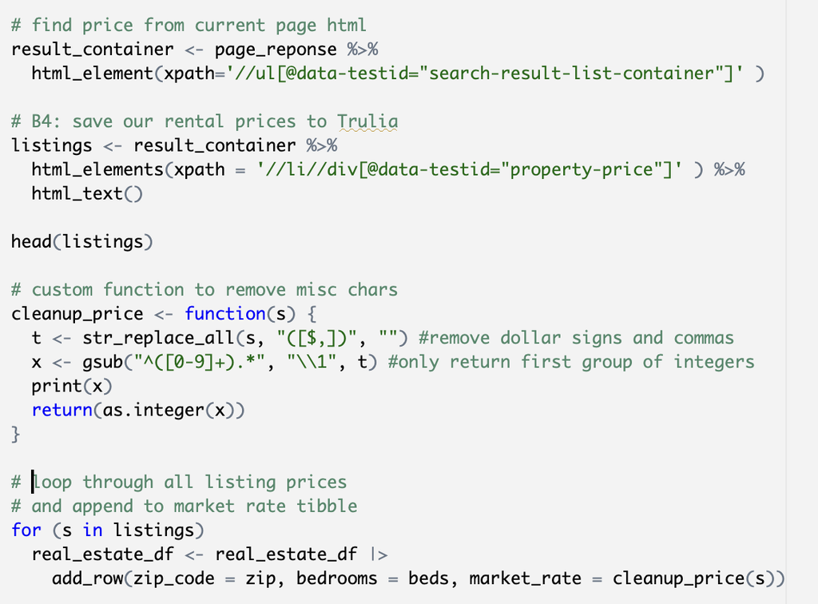

## Scraping Trulia (Cont.)

```
## # A tibble: 10 × 3
##    zip_code bedrooms market_rate
##    <chr>       <dbl>       <int>
##  1 30002           2        2250
##  2 30002           2        1900
##  3 30002           2        1950
##  4 30002           2        1200
##  5 30002           2        1200
##  6 30002           2        1286
##  7 30002           2        1570
##  8 30002           2        1450
##  9 30002           2        1923
## 10 30002           2        2420
```

## Calculating th 40th Percentile for Market Rates

```r
# group by zip codes and # bedrooms
market_rate_by_zip_and_num_bds <- market_rates |>
  group_by(across(all_of(c("zip_code", "bedrooms")))) |>
  summarise(
    market_rate = round(quantile(market_rate,probs=0.4))
  )
head(market_rate_by_zip_and_num_bds)
```

```
## # A tibble: 6 × 3
## # Groups:   zip_code [3]
##   zip_code bedrooms market_rate
##   <chr>       <int>       <dbl>
## 1 14001           1        1040
## 2 14001           2        1145
## 3 14004           1        1748
## 4 14004           2        1750
## 5 14006           1        1159
## 6 14006           2        1315
```

## Joining dataframes

```r
# Combine FMR and Market Rate Dataframes By Zip Code
combined_df_by_zip <- metro_fmr_by_zip_and_num_bds |>
  right_join(market_rate_by_zip_and_num_bds, by= c('zip_code'='zip_code', 'bedrooms'='bedrooms')) |>
  mutate(bedrooms = as.factor(bedrooms))

# C4: pivot longer by estimate type
combined_df_by_zip_and_type <- combined_df_by_zip |>
  pivot_longer(
    cols = c(fmr, market_rate),
    names_to = c("type"),
    values_to = "rent"
  )
```

```
## # A tibble: 6 × 5
##   area_name                     zip_code bedrooms type         rent
##   <chr>                         <chr>    <fct>    <chr>       <dbl>
## 1 Atlanta-Sandy Springs-Roswell 30002    0        fmr          1100
## 2 Atlanta-Sandy Springs-Roswell 30002    0        market rate  1398
## 3 Atlanta-Sandy Springs-Roswell 30002    1        fmr          1150
## 4 Atlanta-Sandy Springs-Roswell 30002    1        market rate  1360
## 5 Atlanta-Sandy Springs-Roswell 30002    2        fmr          1270
## 6 Atlanta-Sandy Springs-Roswell 30002    2        market rate  1675
```

## Plotting the Distribution of Estimate Types

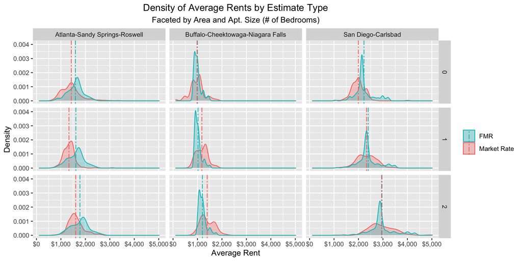

## Count of Zip Codes for Each Estimate Type

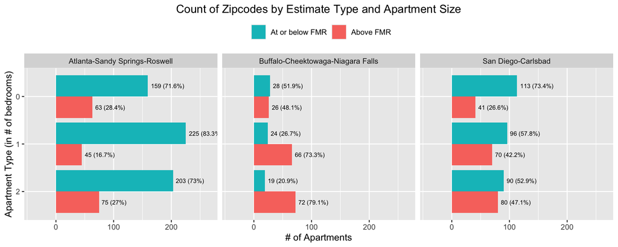

## Absolute Dollar Difference

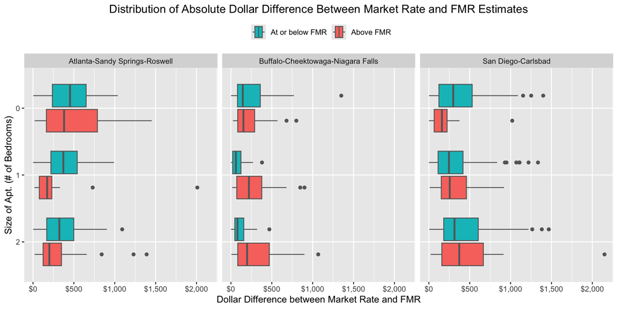

## What is the Median Rent Difference Above FMR?

```
## [1] "Groups of Interest where Mark Rate Exceeded FMR"
```

| Area | Bedrooms | FMR | Median $Diff Above FMR |
| --- | --- | --- | --- |
| Buffalo-Cheektowaga-Niagara Falls | 1 | $990 | $220 |
| Buffalo-Cheektowaga-Niagara Falls | 2 | $1180 | $198 |

```
## [1] "Groups of Interest where FMR Exceeded Market Rates"
```

| Area | Bedrooms | FMR | Median $Diff Below FMR | Median $Diff Above FMR |
| --- | --- | --- | --- | --- |
| San Diego-Carlsbad | 2 | $2880 | $314 | $372 |

## Conclusion & Limitations

- Analysis is based on a “snapshot” of parsed data on December 12th showing only a sample of current listings.
- Some zip codes had no rental listings available on that particular day.
- AJAX pagination issues
- Should collect real estate data over time to better represent real market conditions. Alt. use time-series data like the Zillow Observed Rent Index (ZORI).
- Future work: Expand to include 3/4 bedroom apartments and other metropolitan areas